# Binary choice and ordered choice estimation

林茂廷老師

# 二元選擇模型

清除記憶體，並載入資料  
Grade - binary variable indicating whether or not a student’s grade improved. 1 indicates an improvement.  
TUCE - Test score on economics test  
PSI - participation in program  
GPA - Student’s grade point average

```r
rm(list=ls())
library(dplyr)
library(ggplot2)
file.name<-file.path(getwd(),"Spector and Mazzeo 1980.csv")
data.set <- read.csv(file.name)
```

# 初步資料觀察

先看看有無參加PSI補救課程的人，成績是否改善的次數分配表。首先，將PSI與GRADE改成factor class。

將PSI與GRADE改成factor class

```r
factor(data.set$PSI) -> data.set$PSI
factor(data.set$GRADE) -> data.set$GRADE
```

magrittr套件可以使用更多pipeline語法。  
* `%<>%` 處理完回傳  
使用pipeline

```r
library(magrittr)
data.set$PSI %<>% factor()
data.set$GRADE %<>% factor()
```

察看次數分配

```r
data.set %>%  dplyr::select(PSI,GRADE) %>%
  table() -> tb1; tb1
```

```
   GRADE
PSI  0  1
  0 15  3
  1  6  8
```

有參加與沒參加PSI的人，成績有進步GRADE=1的比例。

```r
tb1 %>% prop.table(margin=1) %>% # row 為條件狀況
  addmargins(margin=2) # 增加一個 column margin
```

```
   GRADE
PSI         0         1       Sum
  0 0.8333333 0.1666667 1.0000000
  1 0.4285714 0.5714286 1.0000000
```

成績有進步的人，有多少比例有參加PSI

```r
tb1 %>% prop.table(margin=2) %>% # column 為條件狀況
  addmargins(margin=1) # 增加一個 row margin
```

```
     GRADE
PSI           0         1
  0   0.7142857 0.2727273
  1   0.2857143 0.7272727
  Sum 1.0000000 1.0000000
```

# 遺漏變數憂慮

過去的GPA是否會造成遺漏變數偏誤  
檢驗GPA與PSI的關係

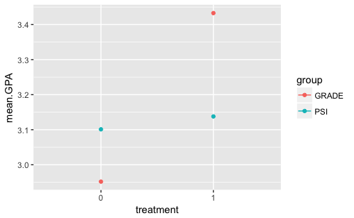

```r
data.set %>% group_by(PSI) %>%
  summarise(mean.GPA=mean(GPA),group="PSI") %>%
  rename(treatment=PSI)-> sumPSI
data.set %>% group_by(GRADE) %>%
  summarise(mean.GPA=mean(GPA),group="GRADE") %>%
  rename(treatment=GRADE) -> sumGRADE
summary.both<-rbind(sumPSI,sumGRADE)
summary.both %>%
  ggplot(aes(x=treatment,y=mean.GPA,color=group)) +
  geom_line()+
  geom_point() -> f.nogroup; f.nogroup
```

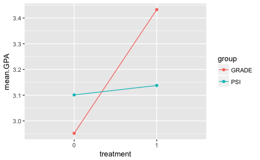

```r
summary.both %>%
  ggplot(aes(x=treatment,y=mean.GPA,color=group,group=group)) +
  geom_line()+
  geom_point() -> f.group; f.group
```

估計模型
$$\Pr(GRADE=1)=F(\beta_0+\beta_1 GPA+\beta_2 TUCE+\beta_3 PSI)$$
使用Logit模型

```r
Logit<-glm(GRADE~GPA+TUCE+PSI,data=data.set,family=binomial(link='logit'))
```

接下來我們會用到pscl與mfx套件來記算其他統計量  
計算(McFadden)Pseudo-R2

```r
library(pscl)
pR2(Logit)->R2.result; R2.result #計算Pseudo-R2
```

```
        llh     llhNull          G2    McFadden        r2ML
-12.8896342 -20.5917297  15.4041909   0.3740383   0.3820705
       r2CU
  0.5277965
```

Pseudo-R2為0.3740383

計算預測準確率  
Null Model: 沒有帶解釋變數的模型

```r
hitmiss(Logit) #計算預測準確率
```

```
Classification Threshold = 0.5
       y=0 y=1
yhat=0  18   3
yhat=1   3   8
Percent Correctly Predicted = 81.25%
Percent Correctly Predicted = 85.71%, for y = 0
Percent Correctly Predicted = 72.73%  for y = 1
Null Model Correctly Predicts 65.62%
[1] 81.25000 85.71429 72.72727
```

計算’代表性個人’邊際效果

```r
library(mfx)
logitmfx(Logit,data.set,atmean=TRUE)-> result.atmean; result.atmean #計算'代表性個人'邊際效果
```

```
Call:
logitmfx(formula = Logit, data = data.set, atmean = TRUE)

Marginal Effects:
        dF/dx Std. Err.      z   P>|z|
GPA  0.533859  0.237037 2.2522 0.02431 *
TUCE 0.017975  0.026237 0.6851 0.49326
PSI1 0.456498  0.181053 2.5214 0.01169 *
---
Signif. codes:  0 ‘***’ 0.001 ‘**’ 0.01 ‘*’ 0.05 ‘.’ 0.1 ‘ ’ 1

dF/dx is for discrete change for the following variables:

[1] "PSI1"
```

平均性代表性個人，(1) 過去GPA每上升0.1時，其成績進步的可能性會上升0.0533859; (2) 過去TUCE每上升1分時，其成績進步的可能性會上升0.0179755； (3) 有參與PSI比沒參與PSI的人，其成績進步的可能性會上升0.4564984。

計算全體邊際效果的平均

```r
logitmfx(Logit,data.set,atmean=FALSE) #計算全體邊際效果的平均
```

```
Call:
logitmfx(formula = Logit, data = data.set, atmean = FALSE)

Marginal Effects:
        dF/dx Std. Err.      z   P>|z|
GPA  0.362581  0.240049 1.5104 0.13093
TUCE 0.012208  0.019036 0.6413 0.52131
PSI1 0.357515  0.142003 2.5177 0.01181 *
---
Signif. codes:  0 ‘***’ 0.001 ‘**’ 0.01 ‘*’ 0.05 ‘.’ 0.1 ‘ ’ 1

dF/dx is for discrete change for the following variables:

[1] "PSI1"
```

使用Probit模型

```r
Probit<-glm(GRADE~GPA+TUCE+PSI,data=data.set,family=binomial(link='probit'))
pR2(Probit)
```

```
       llh    llhNull         G2   McFadden       r2ML       r2CU
-12.818804 -20.591730  15.545851   0.377478   0.384800   0.531567
```

```r
hitmiss(Probit)
```

```
Classification Threshold = 0.5
       y=0 y=1
yhat=0  18   3
yhat=1   3   8
Percent Correctly Predicted = 81.25%
Percent Correctly Predicted = 85.71%, for y = 0
Percent Correctly Predicted = 72.73%  for y = 1
Null Model Correctly Predicts 65.62%
[1] 81.25000 85.71429 72.72727
```

```r
probitmfx(Probit,data.set)
```

```
Call:
probitmfx(formula = Probit, data = data.set)

Marginal Effects:
        dF/dx Std. Err.      z    P>|z|
GPA  0.533348  0.226667 2.3530 0.018622 *
TUCE 0.016970  0.026322 0.6447 0.519125
PSI1 0.464426  0.171258 2.7119 0.006691 **
---
Signif. codes:  0 ‘***’ 0.001 ‘**’ 0.01 ‘*’ 0.05 ‘.’ 0.1 ‘ ’ 1

dF/dx is for discrete change for the following variables:

[1] "PSI1"
```

報表比較  
不同模型設定的係數比較無意義。

```r
library(stargazer)
stargazer(Logit,Probit,type='text',summary=TRUE)
```

```
the condition has length > 1 and only the first element will be usedthe condition has length > 1 and only the first element will be used
```

```
==============================================
                      Dependent variable:
                  ----------------------------
                             GRADE
                     logistic       probit
                       (1)            (2)
----------------------------------------------
GPA                  2.826**        1.626**
                     (1.263)        (0.690)

TUCE                  0.095          0.052
                     (0.142)        (0.081)

PSI1                 2.379**        1.426**
                     (1.065)        (0.587)

Constant            -13.021***     -7.452***
                     (4.931)        (2.572)

----------------------------------------------
Observations            32            32
Log Likelihood       -12.890        -12.819
Akaike Inf. Crit.     33.779        33.638
==============================================
Note:              *p<0.1; **p<0.05; ***p<0.01
```

# 多元可排序選擇模型

戴入使用套件MASS與資籵

```r
library(MASS)
data.set2<-read.csv("German Health Care Utilization.csv")
```

將應變數改成ordered格式

```r
data.set2$hsat %<>% as.ordered()
```

Ordered Logit估計

```r
o.logit<-polr(hsat~age+hhninc+hhkids+educ+married+working,
     data.set2)
pR2(o.logit)
```

```
          llh       llhNull            G2      McFadden
-5.675110e+04 -5.781653e+04  2.130850e+03  1.842769e-02
         r2ML          r2CU
 7.501602e-02  7.612199e-02
```

```r
hitmiss(o.logit)
```

```
Table of Actual (y) Against Predicted (p)
Classification rule: outcome with highest probability.
     p=0 p=1 p=2 p=3 p=4  p=5 p=6 p=7  p=8 p=9 p=10 Row PCP
y=0    0   0   0   0   0  218   0   0  229   0    0  0.0000
y=1    0   0   0   0   0  117   0   0  138   0    0  0.0000
y=2    0   0   0   0   0  273   0   0  369   0    0  0.0000
y=3    0   0   0   0   0  415   0   0  758   0    0  0.0000
y=4    0   0   0   0   0  421   0   0  969   0    0  0.0000
y=5    0   0   0   0   0 1305   0   0 2928   0    0 30.8292
y=6    0   0   0   0   0  679   0   0 1850   0    1  0.0000
y=7    0   0   0   0   0  829   0   0 3398   0    4  0.0000
y=8    0   0   0   0   0  967   0   0 5198   0    7 84.2191
y=9    0   0   0   0   0  310   0   0 2744   0    7  0.0000
y=10   0   0   0   0   0  445   0   0 2742   0    5  0.1566

Percent Correctly Predicted, Fitted Model: 23.82%
Percent Correctly Predicted, Null Model  : 22.59%
```

```r
summary(o.logit)
```

```
Re-fitting to get Hessian
```

```
Call:
polr(formula = hsat ~ age + hhninc + hhkids + educ + married +
    working, data = data.set2)

Coefficients:
             Value Std. Error t value
age     -3.415e-02  9.358e-04 -36.493
hhninc   3.356e-05  2.645e-05   1.269
hhkids   1.086e-01  2.272e-02   4.780
educ     6.270e-02  5.464e-03  11.475
married  3.564e-02  1.450e-02   2.457
working  2.071e-01  2.145e-02   9.658

Intercepts:
     Value      Std. Error t value
0|1     -4.6651     0.0030 -1567.3325
1|2     -4.2007     0.0038 -1098.8068
2|3     -3.5188     0.0068  -514.9999
3|4     -2.8328     0.0245  -115.5271
4|5     -2.3231     0.0278   -83.6877
5|6     -1.3501     0.0297   -45.4665
6|7     -0.9119     0.0302   -30.1585
7|8     -0.2419     0.0310    -7.8116
8|9      0.8482     0.0327    25.9330
9|10     1.6781     0.0353    47.5561

Residual Deviance: 113502.20
AIC: 113534.20
(23725 observations deleted due to missingness)
```

Ordered Probit估計

```r
o.probit<-polr(hsat~age+married,
               data.set2,method='probit')
pR2(o.probit)
```

```
          llh       llhNull            G2      McFadden
-5.700168e+04 -5.781636e+04  1.629347e+03  1.409071e-02
         r2ML          r2CU
 5.788342e-02  5.873681e-02
```

```r
hitmiss(o.probit)
```

```
Table of Actual (y) Against Predicted (p)
Classification rule: outcome with highest probability.
     p=0 p=1 p=2 p=3 p=4 p=5 p=6 p=7  p=8 p=9 p=10 Row PCP
y=0    0   0   0   0   0 103   0   0  344   0    0    0.00
y=1    0   0   0   0   0  61   0   0  194   0    0    0.00
y=2    0   0   0   0   0 145   0   0  497   0    0    0.00
y=3    0   0   0   0   0 247   0   0  926   0    0    0.00
y=4    0   0   0   0   0 262   0   0 1128   0    0    0.00
y=5    0   0   0   0   0 799   0   0 3434   0    0   18.88
y=6    0   0   0   0   0 410   0   0 2120   0    0    0.00
y=7    0   0   0   0   0 531   0   0 3700   0    0    0.00
y=8    0   0   0   0   0 630   0   0 5542   0    0   89.79
y=9    0   0   0   0   0 200   0   0 2861   0    0    0.00
y=10   0   0   0   0   0 272   0   0 2920   0    0    0.00

Percent Correctly Predicted, Fitted Model: 23.21%
Percent Correctly Predicted, Null Model  : 22.59%
```

```r
summary(o.probit)
```

```
Re-fitting to get Hessian
```

```
Call:
polr(formula = hsat ~ age + married, data = data.set2, method = "probit")

Coefficients:
           Value Std. Error t value
age     -0.02263   0.000564 -40.130
married  0.05479   0.014727   3.721

Intercepts:
     Value    Std. Error t value
0|1   -3.1442   0.0326   -96.3322
1|2   -2.9523   0.0310   -95.3164
2|3   -2.6489   0.0293   -90.5455
3|4   -2.3148   0.0281   -82.3381
4|5   -2.0469   0.0275   -74.3689
5|6   -1.4937   0.0267   -55.9570
6|7   -1.2316   0.0264   -46.6766
7|8   -0.8240   0.0260   -31.6987
8|9   -0.1727   0.0257    -6.7167
9|10   0.2864   0.0260    11.0095

Residual Deviance: 114003.37
AIC: 114027.37
(23725 observations deleted due to missingness)
```

比較兩模型

```r
stargazer(o.probit,o.logit,type='text')
```

```
number of rows of result is not a multiple of vector length (arg 2)
```

```
=========================================
                 Dependent variable:
             ----------------------------
                         hsat
                ordered        ordered
                 probit       logistic
                  (1)            (2)
-----------------------------------------
age            -0.023***      -0.034***
                (0.001)        (0.001)

hhninc                         0.00003
                              (0.00003)

hhkids                        0.109***
                               (0.023)

educ                          0.063***
                               (0.005)

married         0.055***       0.036**
                (0.015)        (0.015)

working                       0.207***
                               (0.021)

-----------------------------------------
Observations     27,326        27,326
=========================================
Note:         *p<0.1; **p<0.05; ***p<0.01
```